# London Bike Hire Behavioural Demand Analysis During COVID-19

Analysing bike hire patterns before, during and after COVID-19 restrictions

Piyali Narnaware

U5587270

```r
library(tidyverse)
```

```r
library(ggplot2)
library(dplyr)
library(lubridate)
library(tsibble)
library(forecast)
library(fable)
library(conflicted)
library(lmtest)
#library(car)
library(scales)
```

## Project Overview

This project analyses London bike hire demand between 2010 and 2023, with a focus on how COVID-19 restrictions and behavioural changes influenced daily bike hire patterns.

The analysis explores yearly trends, pre/during/post-COVID demand shifts, policy indicators, regression models and ANOVA-based model comparison.

## Data Dictionary

| Variable | Description |
| --- | --- |
| Date | Date on which the record was created |
| Hires | On particular date number of bikes that were hired |
| schools_closed | This indicates whether the school was open or closed (indicated by 0 or 1) |
| pubs_closed | This indicates whether the pubs was open or closed (indicated by 0 or 1) |
| shops_closed | This indicates whether the shops was open or closed (indicated by 0 or 1) |
| eating_places_closed | This indicates whether the eating places was open or closed (indicated by 0 or 1) |
| stay_at_home | Implementation of Stay home policy on particular date (indicated by 0 or 1) |
| household_mixing_indoors_banned | Indoor household mixing being banned on given date (indicated by 0 or 1) |
| wfh | Work from home regulations on given date (indicated by 0 or 1) |
| rule_of_6_indoors | Implementation of “Rule No.6” on given date (indicated by 0 or 1) |
| curfew | Curfew on given date (indicated by 0 or 1) |
| eat_out_to_help_out | “Eat out to help out” plan implementation on given date (indicated by 0 or 1) |
| day | day on which the record was created |
| month | month - in which the record was created |
| year | year - in which the record was created |

## Data Import

```r
#importing the data from csv file
#using read.csv function for reading the file and saving in variable 'data'
data = read.csv("E:/Git_projects/london_bike_hire/London_COVID_bikes.csv", stringsAsFactors = TRUE)

#using head function to view the first n parts of the data set

head(data)
```

```
##         date Hires schools_closed pubs_closed shops_closed eating_places_closed
## 1 2010-07-30  6897              0           0            0                    0
## 2 2010-07-31  5564              0           0            0                    0
## 3 2010-08-01  4303              0           0            0                    0
## 4 2010-08-02  6642              0           0            0                    0
## 5 2010-08-03  7966              0           0            0                    0
## 6 2010-08-04  7893              0           0            0                    0
##   stay_at_home household_mixing_indoors_banned wfh rule_of_6_indoors curfew
## 1            0                               0   0                 0      0
## 2            0                               0   0                 0      0
## 3            0                               0   0                 0      0
## 4            0                               0   0                 0      0
## 5            0                               0   0                 0      0
## 6            0                               0   0                 0      0
##   eat_out_to_help_out day month year
## 1                   0 Fri   Jul 2010
## 2                   0 Sat   Jul 2010
## 3                   0 Sun   Aug 2010
## 4                   0 Mon   Aug 2010
## 5                   0 Tue   Aug 2010
## 6                   0 Wed   Aug 2010
```

## Data Cleaning and Preparation

```r
#Converting the date into character vector by using as.character
data$date <- as.character(data$date)

#Converting the day into character vector by using as.character
data$day <- as.character(data$day)

#Converting the month into character vector by using as.character
data$month <- as.character(data$month)
```

```r
#finding out total number of missing values in the data set and storing the value in missing_value variable
missing_value <- sum(is.na(data))

#checking the summary of the data set
summary(data)
```

```
##      date               Hires       schools_closed     pubs_closed
##  Length:4812        Min.   :    0   Min.   :0.00000   Min.   :0.00000
##  Class :character   1st Qu.:19776   1st Qu.:0.00000   1st Qu.:0.00000
##  Mode  :character   Median :26356   Median :0.00000   Median :0.00000
##                     Mean   :26607   Mean   :0.02743   Mean   :0.05175
##                     3rd Qu.:33481   3rd Qu.:0.00000   3rd Qu.:0.00000
##                     Max.   :73094   Max.   :1.00000   Max.   :1.00000
##   shops_closed     eating_places_closed  stay_at_home
##  Min.   :0.00000   Min.   :0.00000      Min.   :0.00000
##  1st Qu.:0.00000   1st Qu.:0.00000      1st Qu.:0.00000
##  Median :0.00000   Median :0.00000      Median :0.00000
##  Mean   :0.04634   Mean   :0.05175      Mean   :0.03616
##  3rd Qu.:0.00000   3rd Qu.:0.00000      3rd Qu.:0.00000
##  Max.   :1.00000   Max.   :1.00000      Max.   :1.00000
##  household_mixing_indoors_banned      wfh         rule_of_6_indoors
##  Min.   :0.00000                 Min.   :0.0000   Min.   :0.00000
##  1st Qu.:0.00000                 1st Qu.:0.0000   1st Qu.:0.00000
##  Median :0.00000                 Median :0.0000   Median :0.00000
##  Mean   :0.06525                 Mean   :0.2273   Mean   :0.01995
##  3rd Qu.:0.00000                 3rd Qu.:0.0000   3rd Qu.:0.00000
##  Max.   :1.00000                 Max.   :1.0000   Max.   :1.00000
##      curfew        eat_out_to_help_out     day               month
##  Min.   :0.00000   Min.   :0.000000    Length:4812        Length:4812
##  1st Qu.:0.00000   1st Qu.:0.000000    Class :character   Class :character
##  Median :0.00000   Median :0.000000    Mode  :character   Mode  :character
##  Mean   :0.01164   Mean   :0.005819
##  3rd Qu.:0.00000   3rd Qu.:0.000000
##  Max.   :1.00000   Max.   :1.000000
##       year
##  Min.   :2010
##  1st Qu.:2013
##  Median :2017
##  Mean   :2017
##  3rd Qu.:2020
##  Max.   :2023
```

## Dataset Structure

```r
#understanding the class, format and type of the data set by using str function
str(data)
```

```
## 'data.frame':    4812 obs. of  15 variables:
##  $ date                           : chr  "2010-07-30" "2010-07-31" "2010-08-01" "2010-08-02" ...
##  $ Hires                          : int  6897 5564 4303 6642 7966 7893 8724 9797 6631 7864 ...
##  $ schools_closed                 : int  0 0 0 0 0 0 0 0 0 0 ...
##  $ pubs_closed                    : int  0 0 0 0 0 0 0 0 0 0 ...
##  $ shops_closed                   : int  0 0 0 0 0 0 0 0 0 0 ...
##  $ eating_places_closed           : int  0 0 0 0 0 0 0 0 0 0 ...
##  $ stay_at_home                   : int  0 0 0 0 0 0 0 0 0 0 ...
##  $ household_mixing_indoors_banned: int  0 0 0 0 0 0 0 0 0 0 ...
##  $ wfh                            : int  0 0 0 0 0 0 0 0 0 0 ...
##  $ rule_of_6_indoors              : int  0 0 0 0 0 0 0 0 0 0 ...
##  $ curfew                         : int  0 0 0 0 0 0 0 0 0 0 ...
##  $ eat_out_to_help_out            : int  0 0 0 0 0 0 0 0 0 0 ...
##  $ day                            : chr  "Fri" "Sat" "Sun" "Mon" ...
##  $ month                          : chr  "Jul" "Jul" "Aug" "Aug" ...
##  $ year                           : int  2010 2010 2010 2010 2010 2010 2010 2010 2010 2010 ...
```

```r
# Checking for dates that the repeating in the data set and saving into variable duplicate
#using count function to group the data by date and count the number of rows
#using filter function to keep rows where n is greater than 1 in order to
duplicate <- data %>%
  dplyr::count(date) %>%
  dplyr::filter(n > 1)

# View the duplicates
print(duplicate)
```

```
##         date n
## 1 2021-12-13 2
```

As shown above, the data set contains only one duplicate value for the date “2021-12-13”. Upon careful inspection, we found that the WFH column has different values in the two duplicate rows. We are unable to determine the accuracy of either entry. Hence, we decided not to remove the duplicate rows from the data set.

## Data Preparation and Outlier Review

```r
# converting day and month variable to categorical variable by using factor function
data$day <- factor(data$day, levels = unique(data$day), ordered = TRUE)

data$month <- factor(data$month, levels = unique(data$month), ordered = TRUE)

#check for missing values
sum(is.na(data))
```

```
## [1] 0
```

```r
#displaying the structure of the data
str(data)
```

```
## 'data.frame':    4812 obs. of  15 variables:
##  $ date                           : chr  "2010-07-30" "2010-07-31" "2010-08-01" "2010-08-02" ...
##  $ Hires                          : int  6897 5564 4303 6642 7966 7893 8724 9797 6631 7864 ...
##  $ schools_closed                 : int  0 0 0 0 0 0 0 0 0 0 ...
##  $ pubs_closed                    : int  0 0 0 0 0 0 0 0 0 0 ...
##  $ shops_closed                   : int  0 0 0 0 0 0 0 0 0 0 ...
##  $ eating_places_closed           : int  0 0 0 0 0 0 0 0 0 0 ...
##  $ stay_at_home                   : int  0 0 0 0 0 0 0 0 0 0 ...
##  $ household_mixing_indoors_banned: int  0 0 0 0 0 0 0 0 0 0 ...
##  $ wfh                            : int  0 0 0 0 0 0 0 0 0 0 ...
##  $ rule_of_6_indoors              : int  0 0 0 0 0 0 0 0 0 0 ...
##  $ curfew                         : int  0 0 0 0 0 0 0 0 0 0 ...
##  $ eat_out_to_help_out            : int  0 0 0 0 0 0 0 0 0 0 ...
##  $ day                            : Ord.factor w/ 7 levels "Fri"<"Sat"<"Sun"<..: 1 2 3 4 5 6 7 1 2 3 ...
##  $ month                          : Ord.factor w/ 12 levels "Jul"<"Aug"<"Sep"<..: 1 1 2 2 2 2 2 2 2 2 ...
##  $ year                           : int  2010 2010 2010 2010 2010 2010 2010 2010 2010 2010 ...
```

```r
#in order to check the outliers first lets check the summary of the variable Hires

summary(data$Hires)
```

```
##    Min. 1st Qu.  Median    Mean 3rd Qu.    Max.
##       0   19776   26356   26607   33481   73094
```

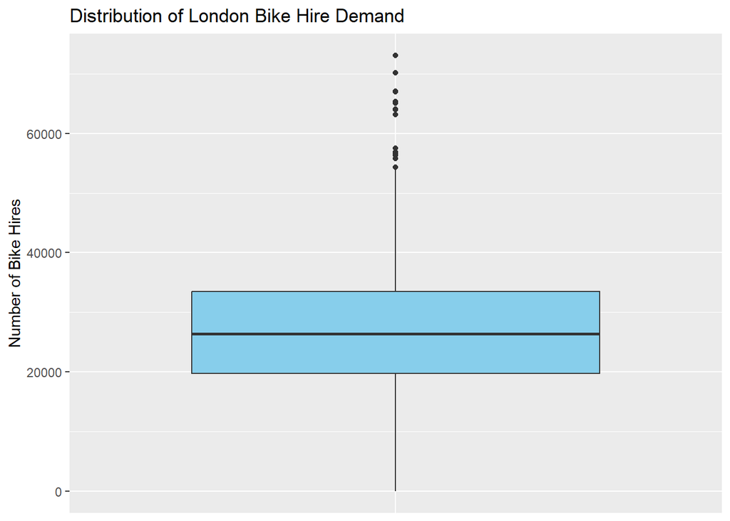

```r
#creating a box plot in order to understand the outliers using function ggplot

ggplot(data, aes(x = "", y = Hires)) +
  geom_boxplot(fill = "skyblue") +
  labs(
    title = "Distribution of London Bike Hire Demand",
    x = NULL,
    y = "Number of Bike Hires"
  ) +
  theme(
    axis.text.x = element_blank(),
    axis.ticks.x = element_blank()
  )
```

```r
#checking for the times when no bikes were rented
zerohire_data <- data[data$Hires == 0, ]
```

```r
#checking for the times when more than 60,000 bikes were rented
highhire_data <- data[data$Hires > 60000,]
```

the number of bikes that is held by the organisation is 1,20,000 and hence more than 60,000 bikes rented in a single day are valid entries

## Yearly Bike Hire Demand

```r
#Aggregating total number of hire for each year
yearlyhired_data <- data %>%
  group_by(year) %>%
  summarise(Hires = sum(Hires))

#displaying the structure
str(yearlyhired_data)
```

```
## tibble [14 × 2] (S3: tbl_df/tbl/data.frame)
##  $ year : int [1:14] 2010 2011 2012 2013 2014 2015 2016 2017 2018 2019 ...
##  $ Hires: int [1:14] 2180813 7142449 9519283 8045459 10023897 9871839 10303637 10446044 10567540 10424955 ...
```

```r
#displaying the summary
summary(yearlyhired_data)
```

```
##       year          Hires
##  Min.   :2010   Min.   : 2180813
##  1st Qu.:2013   1st Qu.: 8413915
##  Median :2016   Median :10163767
##  Mean   :2016   Mean   : 9145323
##  3rd Qu.:2020   3rd Qu.:10443075
##  Max.   :2023   Max.   :11505872
```

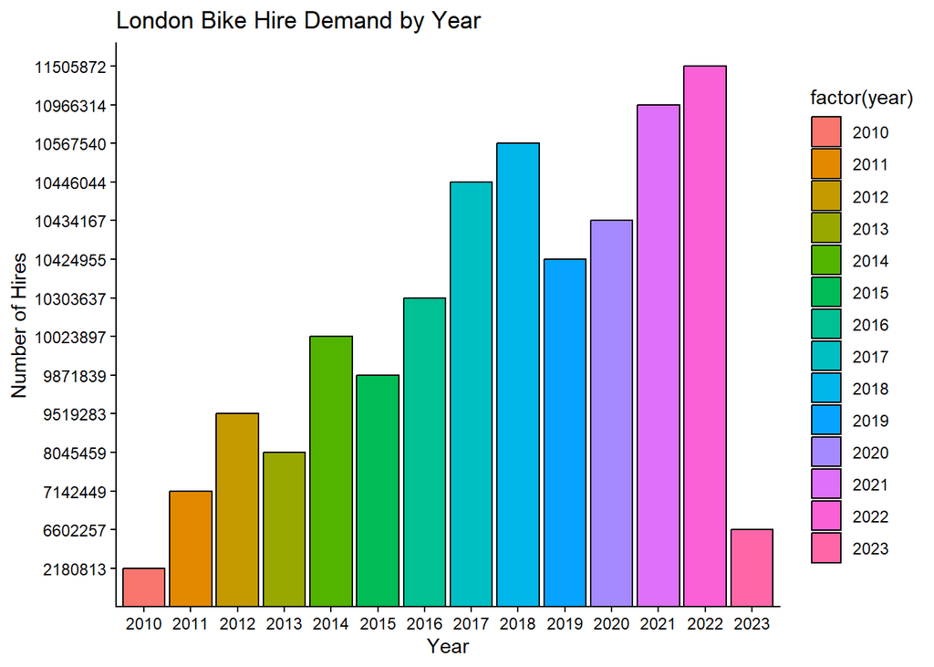

```r
# total number of bikes hired for each year
yearlyhired_data <- aggregate(Hires ~ year, data = data, sum)

ggplot(yearlyhired_data, aes(x = factor(year), y = factor(Hires), fill= factor(year))) + theme_classic() +
  geom_bar(stat = "identity") +
  geom_histogram(stat = "identity", color = "black") +
  labs(x = "Year", y = "Number of Hires", title = "London Bike Hire Demand by Year")
```

## Pre, During and Post-COVID Segmentation

```r
# Pre covid
pre_data <- data %>% dplyr::filter(date < as.Date("2020-03-01"))

str(pre_data)
```

```
## 'data.frame':    3502 obs. of  15 variables:
##  $ date                           : chr  "2010-07-30" "2010-07-31" "2010-08-01" "2010-08-02" ...
##  $ Hires                          : int  6897 5564 4303 6642 7966 7893 8724 9797 6631 7864 ...
##  $ schools_closed                 : int  0 0 0 0 0 0 0 0 0 0 ...
##  $ pubs_closed                    : int  0 0 0 0 0 0 0 0 0 0 ...
##  $ shops_closed                   : int  0 0 0 0 0 0 0 0 0 0 ...
##  $ eating_places_closed           : int  0 0 0 0 0 0 0 0 0 0 ...
##  $ stay_at_home                   : int  0 0 0 0 0 0 0 0 0 0 ...
##  $ household_mixing_indoors_banned: int  0 0 0 0 0 0 0 0 0 0 ...
##  $ wfh                            : int  0 0 0 0 0 0 0 0 0 0 ...
##  $ rule_of_6_indoors              : int  0 0 0 0 0 0 0 0 0 0 ...
##  $ curfew                         : int  0 0 0 0 0 0 0 0 0 0 ...
##  $ eat_out_to_help_out            : int  0 0 0 0 0 0 0 0 0 0 ...
##  $ day                            : Ord.factor w/ 7 levels "Fri"<"Sat"<"Sun"<..: 1 2 3 4 5 6 7 1 2 3 ...
##  $ month                          : Ord.factor w/ 12 levels "Jul"<"Aug"<"Sep"<..: 1 1 2 2 2 2 2 2 2 2 ...
##  $ year                           : int  2010 2010 2010 2010 2010 2010 2010 2010 2010 2010 ...
```

```r
# During Covid
during_data <- data %>% dplyr::filter(year >= 2020) %>%
  dplyr:: filter(date <= as.Date("2021-03-31"))

str(during_data)
```

```
## 'data.frame':    456 obs. of  15 variables:
##  $ date                           : chr  "2020-01-01" "2020-01-02" "2020-01-03" "2020-01-04" ...
##  $ Hires                          : int  11152 18682 18437 15702 12978 23773 27554 28269 26628 26848 ...
##  $ schools_closed                 : int  0 0 0 0 0 0 0 0 0 0 ...
##  $ pubs_closed                    : int  0 0 0 0 0 0 0 0 0 0 ...
##  $ shops_closed                   : int  0 0 0 0 0 0 0 0 0 0 ...
##  $ eating_places_closed           : int  0 0 0 0 0 0 0 0 0 0 ...
##  $ stay_at_home                   : int  0 0 0 0 0 0 0 0 0 0 ...
##  $ household_mixing_indoors_banned: int  0 0 0 0 0 0 0 0 0 0 ...
##  $ wfh                            : int  0 0 0 0 0 0 0 0 0 0 ...
##  $ rule_of_6_indoors              : int  0 0 0 0 0 0 0 0 0 0 ...
##  $ curfew                         : int  0 0 0 0 0 0 0 0 0 0 ...
##  $ eat_out_to_help_out            : int  0 0 0 0 0 0 0 0 0 0 ...
##  $ day                            : Ord.factor w/ 7 levels "Fri"<"Sat"<"Sun"<..: 6 7 1 2 3 4 5 6 7 1 ...
##  $ month                          : Ord.factor w/ 12 levels "Jul"<"Aug"<"Sep"<..: 7 7 7 7 7 7 7 7 7 7 ...
##  $ year                           : int  2020 2020 2020 2020 2020 2020 2020 2020 2020 2020 ...
```

```r
# Post Covid
post_data <- data %>% dplyr::filter(date >=as.Date("2021-04-01"))

str(post_data)
```

```
## 'data.frame':    914 obs. of  15 variables:
##  $ date                           : chr  "2021-04-01" "2021-04-02" "2021-04-03" "2021-04-04" ...
##  $ Hires                          : int  36465 39035 33877 47500 26788 22337 24414 27059 30386 23659 ...
##  $ schools_closed                 : int  0 0 0 0 0 0 0 0 0 0 ...
##  $ pubs_closed                    : int  1 1 1 1 1 1 1 1 1 1 ...
##  $ shops_closed                   : int  1 1 1 1 1 1 1 1 1 1 ...
##  $ eating_places_closed           : int  1 1 1 1 1 1 1 1 1 1 ...
##  $ stay_at_home                   : int  0 0 0 0 0 0 0 0 0 0 ...
##  $ household_mixing_indoors_banned: int  1 1 1 1 1 1 1 1 1 1 ...
##  $ wfh                            : int  1 1 1 1 1 1 1 1 1 1 ...
##  $ rule_of_6_indoors              : int  0 0 0 0 0 0 0 0 0 0 ...
##  $ curfew                         : int  0 0 0 0 0 0 0 0 0 0 ...
##  $ eat_out_to_help_out            : int  0 0 0 0 0 0 0 0 0 0 ...
##  $ day                            : Ord.factor w/ 7 levels "Fri"<"Sat"<"Sun"<..: 7 1 2 3 4 5 6 7 1 2 ...
##  $ month                          : Ord.factor w/ 12 levels "Jul"<"Aug"<"Sep"<..: 10 10 10 10 10 10 10 10 10 10 ...
##  $ year                           : int  2021 2021 2021 2021 2021 2021 2021 2021 2021 2021 ...
```

## Plots : Pre-covid

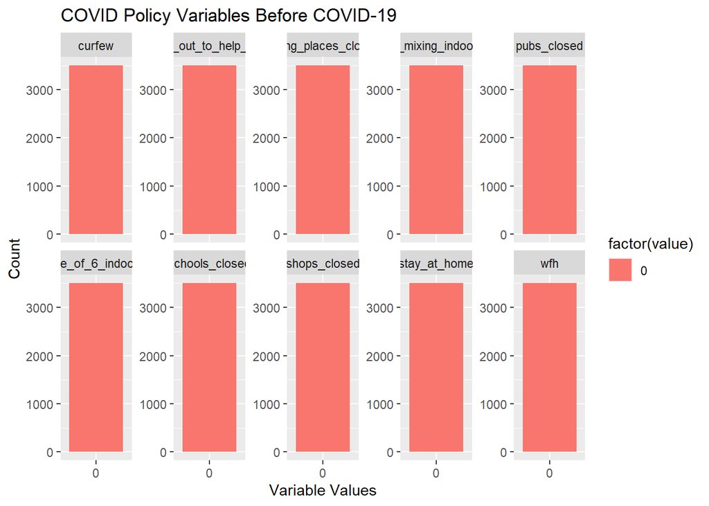

```r
#Plotting for pre covid

data_precovid <- tidyr::pivot_longer(pre_data, cols = c("schools_closed", "pubs_closed", "shops_closed","eating_places_closed", "stay_at_home",                                     "household_mixing_indoors_banned", "wfh",
 "rule_of_6_indoors", "curfew", "eat_out_to_help_out"))

data_precovid_count <- data_precovid %>%
  count(name, value)

ggplot(data_precovid_count, aes(x = factor(value), y = n, fill = factor(value))) +
  geom_col() +
  labs(title = "COVID Policy Variables Before COVID-19",
       x = "Variable Values",
       y = "Count") +
  facet_wrap(~name, scales = "free_y", nrow = 2)
```

## During Covid

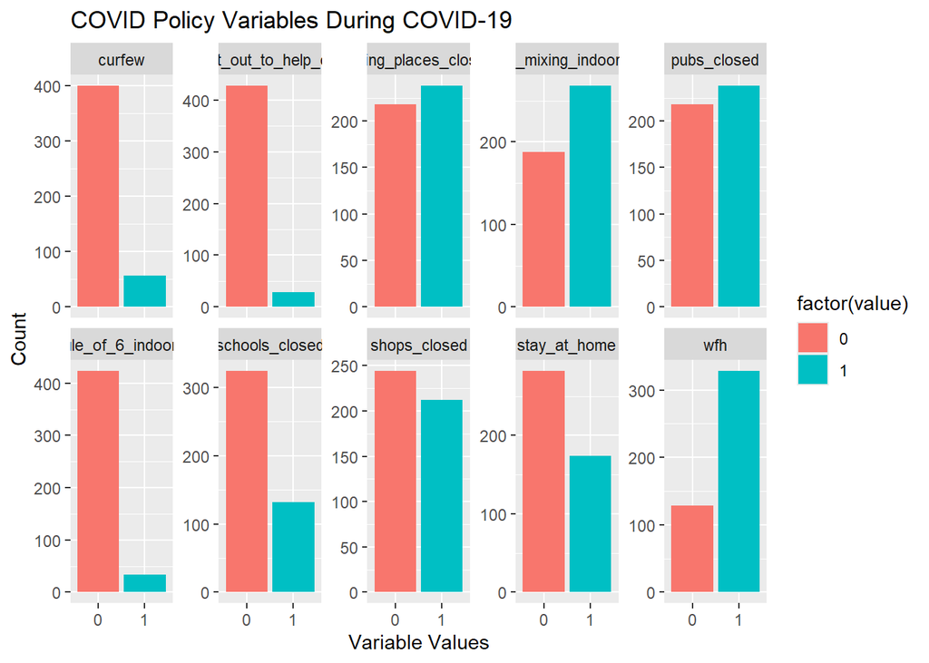

```r
#Plotting for during covid

data_duringcovid <- tidyr::pivot_longer(during_data, cols = c("schools_closed", "pubs_closed", "shops_closed","eating_places_closed", "stay_at_home",                                     "household_mixing_indoors_banned", "wfh",                                    "rule_of_6_indoors", "curfew", "eat_out_to_help_out"))

data_duringcovid_count <- data_duringcovid %>%
  count(name, value)

ggplot(data_duringcovid_count, aes(x = factor(value), y = n, fill = factor(value))) +
  geom_col() +
  labs(title = "COVID Policy Variables During COVID-19",
       x = "Variable Values",
       y = "Count") +
  facet_wrap(~name, scales = "free_y", nrow = 2)
```

## Post Covid

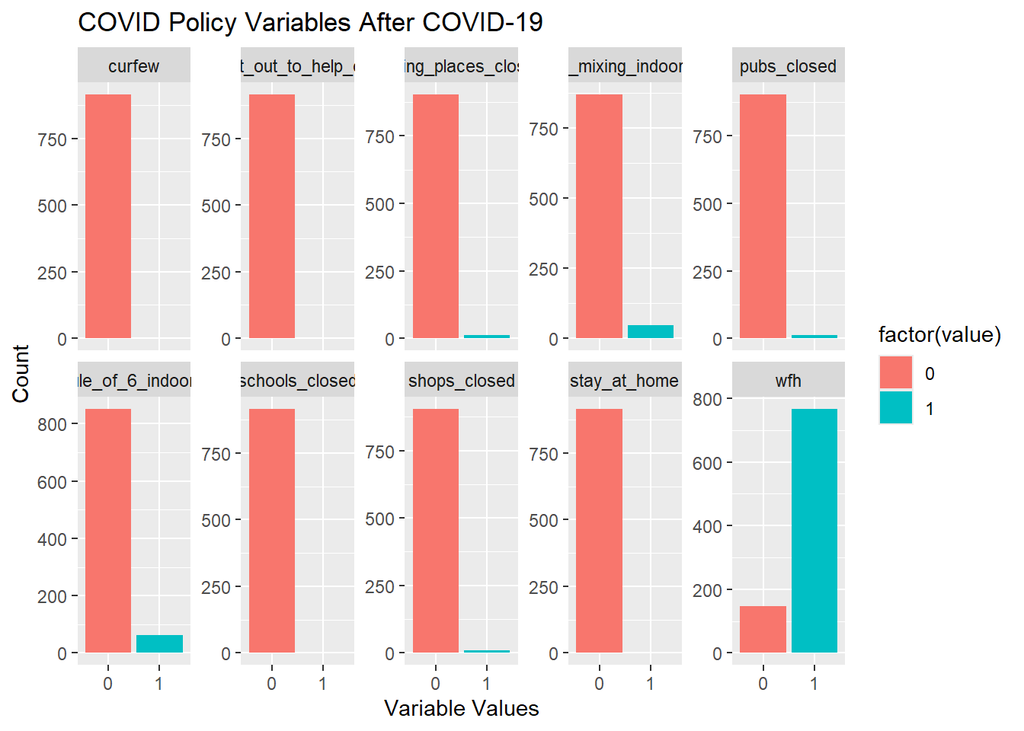

```r
#Plotting for post covid
data_postcovid <- tidyr::pivot_longer(post_data, cols = c("schools_closed", "pubs_closed", "shops_closed","eating_places_closed", "stay_at_home",                                     "household_mixing_indoors_banned", "wfh",
 "rule_of_6_indoors", "curfew", "eat_out_to_help_out"))

data_postcovid_count <- data_postcovid %>%
  count(name, value)

ggplot(data_postcovid_count, aes(x = factor(value), y = n, fill = factor(value))) +
  geom_col() +
  labs(title = "COVID Policy Variables After COVID-19",
       x = "Variable Values",
       y = "Count") +
  facet_wrap(~name, scales = "free_y", nrow = 2)
```

## COVID Policy Timeline

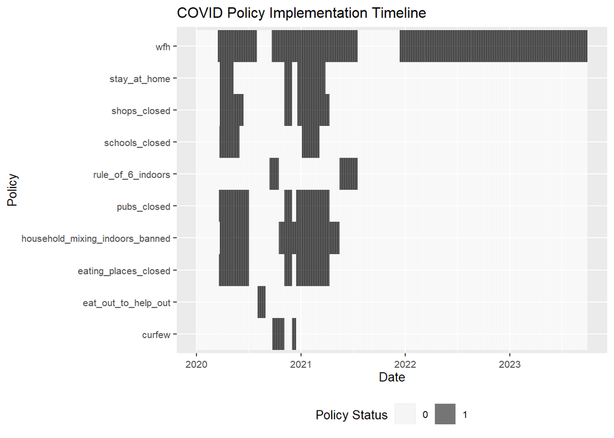

```r
#Reshaping the data for creating timeline
imp_policy_during <- tidyr::pivot_longer(during_data,
           cols = c("schools_closed", "pubs_closed", "shops_closed",                                            "eating_places_closed", "stay_at_home",                                                              "household_mixing_indoors_banned", "wfh",
             "rule_of_6_indoors", "curfew", "eat_out_to_help_out"))

imp_policy_post <-tidyr::pivot_longer(post_data,
           cols = c("schools_closed", "pubs_closed", "shops_closed",                                            "eating_places_closed", "stay_at_home",                                                              "household_mixing_indoors_banned", "wfh",
             "rule_of_6_indoors", "curfew", "eat_out_to_help_out"))

imp_policy <- dplyr::bind_rows(imp_policy_during,imp_policy_post)

# Convert the date column to Date format
imp_policy$date <- as.Date(imp_policy$date)

# Plot the timeline

g1 <- ggplot(imp_policy, aes(x = date, y = name, fill = factor(value))) +
  geom_tile(alpha = 0.5) +
  labs(title = "COVID Policy Implementation Timeline",
       x = "Date",
       y = "Policy",
       fill = "Policy Status") +
  scale_fill_manual(values = c("0" = "white", "1" = "black")) +
  theme(text = element_text(size = 10), # seting the font size for all text elements
        axis.text.x = element_text(angle = 0, vjust = 0.5), # rotate and align the x-axis text
        legend.position = "bottom") # fixing the legend to the bottom

print(g1)
```

## Bike Hire Comparison Before, During and After COVID-19

```r
#combining the before, during and after covid data

combined_data <- bind_rows(
  pre_data = mutate(pre_data, period = " PRE COVID"),
  during_data = mutate(during_data, period = "DURING COVID"),
  post_data = mutate(post_data, period = "POST COVID"),
  .id = "source")

head(combined_data)
```

```
##     source       date Hires schools_closed pubs_closed shops_closed
## 1 pre_data 2010-07-30  6897              0           0            0
## 2 pre_data 2010-07-31  5564              0           0            0
## 3 pre_data 2010-08-01  4303              0           0            0
## 4 pre_data 2010-08-02  6642              0           0            0
## 5 pre_data 2010-08-03  7966              0           0            0
## 6 pre_data 2010-08-04  7893              0           0            0
##   eating_places_closed stay_at_home household_mixing_indoors_banned wfh
## 1                    0            0                               0   0
## 2                    0            0                               0   0
## 3                    0            0                               0   0
## 4                    0            0                               0   0
## 5                    0            0                               0   0
## 6                    0            0                               0   0
##   rule_of_6_indoors curfew eat_out_to_help_out day month year     period
## 1                 0      0                   0 Fri   Jul 2010  PRE COVID
## 2                 0      0                   0 Sat   Jul 2010  PRE COVID
## 3                 0      0                   0 Sun   Aug 2010  PRE COVID
## 4                 0      0                   0 Mon   Aug 2010  PRE COVID
## 5                 0      0                   0 Tue   Aug 2010  PRE COVID
## 6                 0      0                   0 Wed   Aug 2010  PRE COVID
```

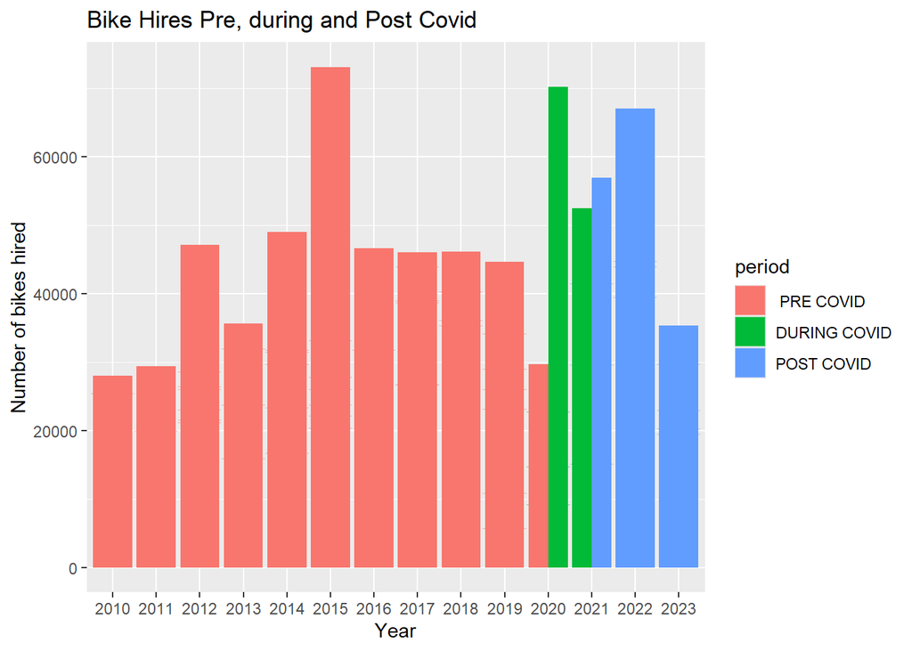

```r
#printing the combined graph to understand the hiring of bikes pre and post covid

g2 <- ggplot(combined_data, aes(x = factor(year), y = Hires, fill = factor(period))) +
   geom_tile(alpha = 0.5) +
  geom_col(position = "dodge") +
  labs(title = "Bike Hires Pre, during and Post Covid",
       x = "Year",
       y = "Number of bikes hired" ,
       fill = "period" )

print(g2)
```

## Regression Analysis

# Regression Model - WFH (Work From Home)

```r
# Regression model : work from home and number of hired bikes
reg_model_wfh <- lm(Hires ~ wfh , data = data)

summary(reg_model_wfh)
```

```
##
## Call:
## lm(formula = Hires ~ wfh, data = data)
##
## Residuals:
##    Min     1Q Median     3Q    Max
## -27974  -6808   -258   6880  46889
##
## Coefficients:
##             Estimate Std. Error t value Pr(>|t|)
## (Intercept)  26205.1      158.6  165.26  < 2e-16 ***
## wfh           1769.1      332.6    5.32 1.09e-07 ***
## ---
## Signif. codes:  0 '***' 0.001 '**' 0.01 '*' 0.05 '.' 0.1 ' ' 1
##
## Residual standard error: 9669 on 4810 degrees of freedom
## Multiple R-squared:  0.005849,   Adjusted R-squared:  0.005642
## F-statistic:  28.3 on 1 and 4810 DF,  p-value: 1.087e-07
```

```r
cbind(coef(reg_model_wfh), confint(reg_model_wfh))
```

```
##                           2.5 %   97.5 %
## (Intercept) 26205.149 25894.287 26516.01
## wfh          1769.059  1117.097  2421.02
```

# Regression Model - WFH (Work From Home) - yearly basis

```r
reg_model_wfh_year <- lm(Hires ~ wfh *as.factor(year), data = data)

summary(reg_model_wfh_year)
```

```
##
## Call:
## lm(formula = Hires ~ wfh * as.factor(year), data = data)
##
## Residuals:
##    Min     1Q Median     3Q    Max
## -31523  -5574     31   6096  46048
##
## Coefficients: (12 not defined because of singularities)
##                         Estimate Std. Error t value Pr(>|t|)
## (Intercept)              14069.8      708.9  19.847  < 2e-16 ***
## wfh                      -8596.0      940.0  -9.144  < 2e-16 ***
## as.factor(year)2011       5498.6      846.2   6.498 8.95e-11 ***
## as.factor(year)2012      11939.2      845.8  14.116  < 2e-16 ***
## as.factor(year)2013       7972.6      846.2   9.422  < 2e-16 ***
## as.factor(year)2014      13393.0      846.2  15.828  < 2e-16 ***
## as.factor(year)2015      12976.4      846.2  15.336  < 2e-16 ***
## as.factor(year)2016      14082.3      845.8  16.649  < 2e-16 ***
## as.factor(year)2017      14549.5      846.2  17.195  < 2e-16 ***
## as.factor(year)2018      14882.4      846.2  17.588  < 2e-16 ***
## as.factor(year)2019      14491.8      846.2  17.127  < 2e-16 ***
## as.factor(year)2020      14934.9     1054.1  14.168  < 2e-16 ***
## as.factor(year)2021      21012.9     1014.3  20.716  < 2e-16 ***
## as.factor(year)2022      26049.2     1264.8  20.596  < 2e-16 ***
## as.factor(year)2023      18710.4     1292.9  14.472  < 2e-16 ***
## wfh:as.factor(year)2011       NA         NA      NA       NA
## wfh:as.factor(year)2012       NA         NA      NA       NA
## wfh:as.factor(year)2013       NA         NA      NA       NA
## wfh:as.factor(year)2014       NA         NA      NA       NA
## wfh:as.factor(year)2015       NA         NA      NA       NA
## wfh:as.factor(year)2016       NA         NA      NA       NA
## wfh:as.factor(year)2017       NA         NA      NA       NA
## wfh:as.factor(year)2018       NA         NA      NA       NA
## wfh:as.factor(year)2019       NA         NA      NA       NA
## wfh:as.factor(year)2020   7833.3     1348.9   5.807 6.76e-09 ***
## wfh:as.factor(year)2021       NA         NA      NA       NA
## wfh:as.factor(year)2022       NA         NA      NA       NA
## wfh:as.factor(year)2023       NA         NA      NA       NA
## ---
## Signif. codes:  0 '***' 0.001 '**' 0.01 '*' 0.05 '.' 0.1 ' ' 1
##
## Residual standard error: 8826 on 4796 degrees of freedom
## Multiple R-squared:  0.174,  Adjusted R-squared:  0.1714
## F-statistic: 67.36 on 15 and 4796 DF,  p-value: < 2.2e-16
```

```r
cbind(coef(reg_model_wfh_year), confint(reg_model_wfh_year))
```

```
##                                        2.5 %    97.5 %
## (Intercept)             14069.761  12679.965 15459.558
## wfh                     -8596.045 -10438.932 -6753.159
## as.factor(year)2011      5498.592   3839.744  7157.440
## as.factor(year)2012     11939.209  10281.037 13597.381
## as.factor(year)2013      7972.592   6313.744  9631.440
## as.factor(year)2014     13392.970  11734.123 15051.818
## as.factor(year)2015     12976.373  11317.525 14635.221
## as.factor(year)2016     14082.252  12424.080 15740.424
## as.factor(year)2017     14549.537  12890.690 16208.385
## as.factor(year)2018     14882.403  13223.555 16541.251
## as.factor(year)2019     14491.759  12832.912 16150.607
## as.factor(year)2020     14934.879  12868.360 17001.399
## as.factor(year)2021     21012.894  19024.320 23001.468
## as.factor(year)2022     26049.221  23569.704 28528.738
## as.factor(year)2023     18710.376  16175.731 21245.020
## wfh:as.factor(year)2011        NA         NA        NA
## wfh:as.factor(year)2012        NA         NA        NA
## wfh:as.factor(year)2013        NA         NA        NA
## wfh:as.factor(year)2014        NA         NA        NA
## wfh:as.factor(year)2015        NA         NA        NA
## wfh:as.factor(year)2016        NA         NA        NA
## wfh:as.factor(year)2017        NA         NA        NA
## wfh:as.factor(year)2018        NA         NA        NA
## wfh:as.factor(year)2019        NA         NA        NA
## wfh:as.factor(year)2020  7833.308   5188.855 10477.761
## wfh:as.factor(year)2021        NA         NA        NA
## wfh:as.factor(year)2022        NA         NA        NA
## wfh:as.factor(year)2023        NA         NA        NA
```

# Regression Model - WFH (Work From Home) - monthly basis

```r
reg_model_wfh_month <- lm(Hires ~ wfh *as.character(month), data = data)

summary(reg_model_wfh_month)
```

```
##
## Call:
## lm(formula = Hires ~ wfh * as.character(month), data = data)
##
## Residuals:
##    Min     1Q Median     3Q    Max
## -29298  -5151    523   5600  38232
##
## Coefficients:
##                            Estimate Std. Error t value Pr(>|t|)
## (Intercept)                 26005.1      472.0  55.097  < 2e-16 ***
## wfh                           770.2      850.9   0.905  0.36542
## as.character(month)Aug       5388.0      620.1   8.690  < 2e-16 ***
## as.character(month)Dec      -8843.1      639.5 -13.828  < 2e-16 ***
## as.character(month)Feb      -6211.5      659.8  -9.414  < 2e-16 ***
## as.character(month)Jan      -7273.4      645.6 -11.266  < 2e-16 ***
## as.character(month)Jul       8857.1      653.7  13.549  < 2e-16 ***
## as.character(month)Jun       6043.4      667.5   9.054  < 2e-16 ***
## as.character(month)Mar      -3683.4      653.2  -5.639 1.81e-08 ***
## as.character(month)May       3798.3      662.1   5.737 1.02e-08 ***
## as.character(month)Nov      -2945.2      636.4  -4.628 3.80e-06 ***
## as.character(month)Oct       1670.3      631.8   2.644  0.00823 **
## as.character(month)Sep       5133.9      627.8   8.178 3.67e-16 ***
## wfh:as.character(month)Aug    712.1     1362.3   0.523  0.60121
## wfh:as.character(month)Dec   -399.7     1285.6  -0.311  0.75589
## wfh:as.character(month)Feb   1748.9     1285.5   1.360  0.17374
## wfh:as.character(month)Jan   -904.8     1250.9  -0.723  0.46951
## wfh:as.character(month)Jul    319.0     1212.6   0.263  0.79254
## wfh:as.character(month)Jun   4740.5     1203.3   3.939 8.28e-05 ***
## wfh:as.character(month)Mar   1206.6     1218.5   0.990  0.32211
## wfh:as.character(month)May   2216.0     1193.6   1.857  0.06343 .
## wfh:as.character(month)Nov    933.3     1381.6   0.676  0.49939
## wfh:as.character(month)Oct   -822.9     1367.7  -0.602  0.54741
## wfh:as.character(month)Sep  -3759.8     1329.3  -2.828  0.00470 **
## ---
## Signif. codes:  0 '***' 0.001 '**' 0.01 '*' 0.05 '.' 0.1 ' ' 1
##
## Residual standard error: 7756 on 4788 degrees of freedom
## Multiple R-squared:  0.3633, Adjusted R-squared:  0.3602
## F-statistic: 118.8 on 23 and 4788 DF,  p-value: < 2.2e-16
```

```r
cbind(coef(reg_model_wfh_month), confint(reg_model_wfh_month))
```

```
##                                             2.5 %    97.5 %
## (Intercept)                26005.0556  25079.7425 26930.369
## wfh                          770.1944   -897.9374  2438.326
## as.character(month)Aug      5387.9848   4172.4014  6603.568
## as.character(month)Dec     -8843.0710 -10096.8321 -7589.310
## as.character(month)Feb     -6211.4690  -7504.9440 -4917.994
## as.character(month)Jan     -7273.4007  -8539.0747 -6007.727
## as.character(month)Jul      8857.1145   7575.5084 10138.721
## as.character(month)Jun      6043.4481   4734.8579  7352.038
## as.character(month)Mar     -3683.3674  -4963.9332 -2402.802
## as.character(month)May      3798.2993   2500.3051  5096.294
## as.character(month)Nov     -2945.1616  -4192.8535 -1697.470
## as.character(month)Oct      1670.2876    431.6846  2908.890
## as.character(month)Sep      5133.9274   3903.1459  6364.709
## wfh:as.character(month)Aug   712.0556  -1958.6623  3382.773
## wfh:as.character(month)Dec  -399.6975  -2920.0924  2120.697
## wfh:as.character(month)Feb  1748.9452   -771.2973  4269.188
## wfh:as.character(month)Jan  -904.8385  -3357.2138  1547.537
## wfh:as.character(month)Jul   318.9598  -2058.3565  2696.276
## wfh:as.character(month)Jun  4740.5019   2381.4072  7099.597
## wfh:as.character(month)Mar  1206.6267  -1182.2683  3595.522
## wfh:as.character(month)May  2216.0475   -123.9449  4556.040
## wfh:as.character(month)Nov   933.2616  -1775.2645  3641.788
## wfh:as.character(month)Oct  -822.9246  -3504.1983  1858.349
## wfh:as.character(month)Sep -3759.7571  -6365.8359 -1153.678
```